# PSGY4009

Experimental design for functional imaging

Author

Denis Schluppeck

Published

September 30, 2025

## 1 Today

- Who am I? Who is everyone?
- A quick overview of the module.
- What to expect, assessment/coursework?
- 101 of functional MRI and experiment design.

## 2 Overview

| Timetable week | Date | Lecture | Lecturer | Lecture |
| --- | --- | --- | --- | --- |
| 02 | 2025-09-30 | 1 | Schluppeck / Griffiths | Overview, **fMRI & study design.** |
| 03 | 2025-10-07 | 2 | M Schürmann | **Basic neuroanatomy** |
| 04 | 2025-10-14 | 3 | D Venerio | **Brain stimulation & study design.** |
| 05 | 2025-10-21 | 4 | W v Heuven | **Language** |
| 06 | 2025-10-28 |  | **Reading week** (no lecture) |  |
| 07 | 2025-11-04 | 5 | D Schluppeck | **Q&A, experimental design, coursework** |
| 08 | 2025-11-11 | 6 | L Cragg | **Developmental neuroimaging.** |
| 09 | 2025-11-18 | 7 | B Griffiths | **Vision + brain imaging** |
| 10 | 2025-11-25 | 8 | J Derrfuss | **Cognitive control, attention, and working memory.** |
| 11 | 2025-12-02 | 9 | R Filik | **Moral Cognition** |
| 12 | 2025-12-09 | 10 | M Ashgar / D Schluppeck | Module recap, **Touch / Somatosensation** (+- decision making) |

## 3 Assessment

- Written assignment (max 3000 words) including a 250 word abstract.
- Details on [moodle (2024/25)](https://moodle.nottingham.ac.uk/course/view.php?id=137637).

. . .

### 3.1 What? How?

> How can fMRI and/or brain stimulation be used to study different neuroscience questions? Cover at least two topics and/or methods from the course.

## 4 Today’s lecture

- A brief introduction to fMRI.
- Scope and limitations of the fMRI method.
- Principles of experimental design in psychology.
- Experimental design for fMRI.

## 5 Learning objectives

By the end of the lecture you should be able to:

- Understand what fMRI measures.
- Evaluate the strengths and weaknesses of fMRI.
- Evaluate different experimental designs.

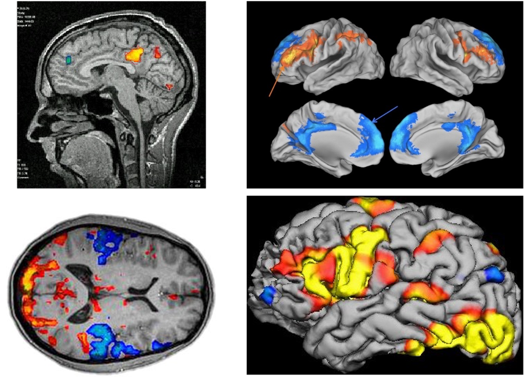

image of statistical maps on brains

## 6 LO

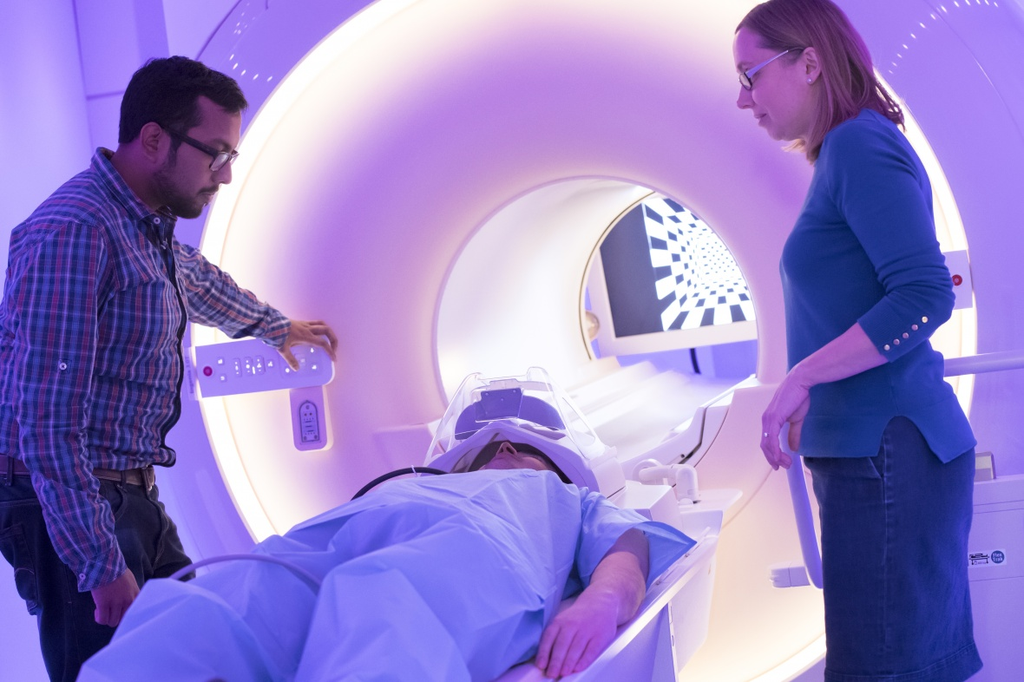

person being positioned in an MRI scanner

fMRI basics

## 7 fMRI basics

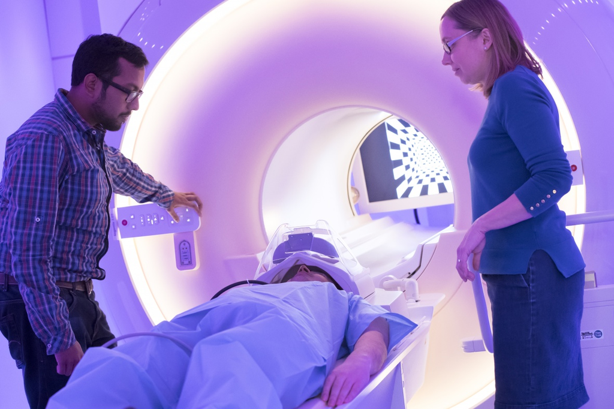

person being positioned in an MRI scanner

- MRI uses **static** and **oscillating** electromagnetic fields to detect different biological tissue properties.
- **functional MRI** measures changes in blood oxygenation over time.
- BOLD signal: blood oxygen level dependent

## 8 Example research questions

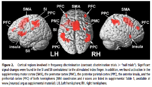

**Where** are the areas more active in **Condition A** than in **Condition B**?

[figure not shown]

How do pre-defined **regions of interest** respond in different experimental conditions?

## 9 Experimental “pipeline”

**Prepare**

Theory ➡️ Research Question ➡️ Hypothesis

**Plan & do**

Experimental Design ➡️ Piloting ➡️ Data collection

**Analyse & report**

Preprocessing ➡️ Analysis ➡️ Interpretation

General overview of how imaging experiments often work / get designed.

## 10 Study

[figure not shown]

diagram from textbook showing study design ideas

## 11 General thoughts (BOLD)

What does the blood-oxygen-level-dependent (BOLD) signal measure?

- neuronal activity?!
- populations of neurons (excitatory, inhibitory)
- spikes or (pre-)synaptic activity

## 12 General thoughts (Signal/Noise)

(fMRI) signals are weak + noisy.

- How does that limit voxel size?
- Short events, minimum durations?
- Need for averaging?
- Blocks versus “event-related” designs?

## 13 General thoughts (Variability)

Details of brain anatomy vary across individuals.

- What does this mean for group studies?
- Individual subjects results first?
- Data in 3d or 2d (cortical surface?)

## 14 Example data / images

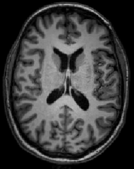

Anatomical image (T1w)

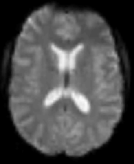

Functional image (T2*, EPI)

## 15 fMRI measures changes over time

## 16 Example: visual cortex

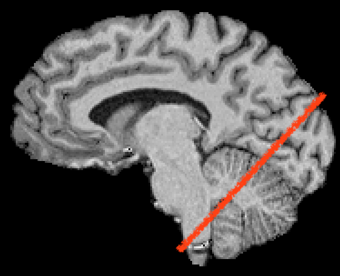

anatomical image with position of fMRI slice

## 17 Example: visual cortex (movie)

[figure not shown]

## 18 fMRI measures changes over time

## 19 “There is no free lunch”

- both, *spatial resolution* and *temporal resolution*, are limited
- often, experimenter has to trade off one against the other
- so, different choices for different applications…

## 20 Why do we need high spatial resolution?

- brain structures of interest are ~mm in size, sometimes separated by ~cm; need appropriate sampling
- smaller voxels: less mixing of grey matter, white matter, CSF, veins, … reduced partial voluming

## 21 Appropriate sampling

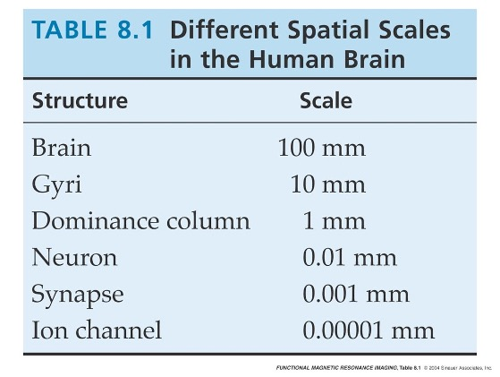

Table of structures / sizes

## 22 Volume → no. of cells

… if packing density in grey matter of cortex is ~50,000 cells / mm$^3$

| edge (mm) | volume (mm$^3$) | #cells in pure GM |
| --- | --- | --- |
| 1 | 1 | 50k |
| 3 | 27 | 1.35M |
| 5 | 125 | 6.25M |

## 23 PVE

## 24 Partial volume effects

[figure not shown]

A typical 3mm voxel contains a mixture of tissues

## 25 What limits (spatial) resolution

**hardware** (the scanner)

**the subjects**

- peripheral nerve stimulation PNS
- specific absorption rate SAR limits
- time in scanner ( >1.5h is not fun)

**signal-to-noise ratio** - smaller voxels = proportionally more noise head motion, physiology, …

## 26 fMRI measures changes over time

## 27 What limits (temporal) resolution

**Importantphysiology**

basis of the blood-oxygen-level-dependent (BOLD) signal

- BOLD is **haemodynamic**, an indirect measure of neural activity (+ still hotly debated)
- BOLD signal is **delayed and blurred** in space, but also in time

## 28 Haemodynamic response

the shape of the response to a brief event is called the haemodynamic response function (HRF)

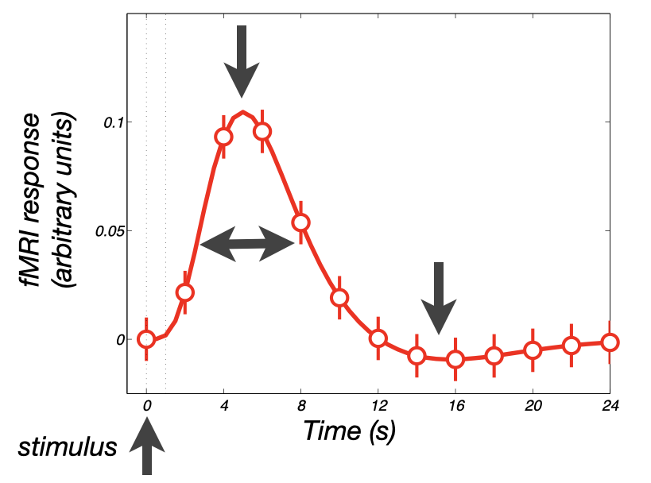

haemodynamic response

e.g. haemodynamic response to a 1s visual stimulus peaks several seconds later and is spread out

## 29 Intermediate summary

- Overview of the fMRI method.
- How to interpret fMRI data.
- Limiting factors of fMRI.
- Trade-off between temporal and spatial resolution.

Thinking about **temporal resolution** particularly important when designing fMRI experiments

## 30 Some principles of experimental design

> Why do we need to worry about designing experiments?

break

## 31 Terminology

**Independent Variable:**

variable which is intentionally manipulated (different manipulations are called conditions / levels)

**Dependent Variable:**

measured variable

**Confound:**

a property that co-varies with the IV

## 32 eg. this experiment

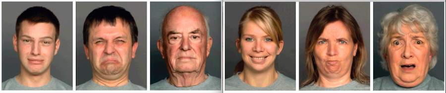

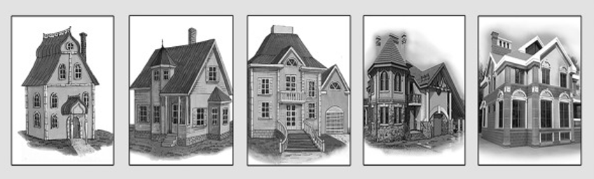

## 33 Dealing with confounds

**Counterbalancing:** a process for removing confounds by ensuring they have equal influence at each level of the IV

**Randomization:** removing confounds by making sure they vary randomly at each level of the IV

## 34 Within or between subjects?

**Within-subjects designs are stronger as they control for:**

- Age Gender.
- Experience.
- Individual Difference.
- Brain size / shape.

**Between-subjects designs are sometime unavoidable**

- Diagnostic comparisons
- Gender effects

Match the design to the research question…

## 35 … and for fMRI?

All the above, plus…

- Selecting an appropriate IV
- Selecting an appropriate control condition
- Types of experimental design
- Stimulus presentation timing

## 36 Many studies: cognitive subtraction

Compare two very similar conditions that are assumed to differ only in one property.

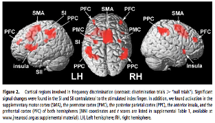

## 37 Control conditions are important

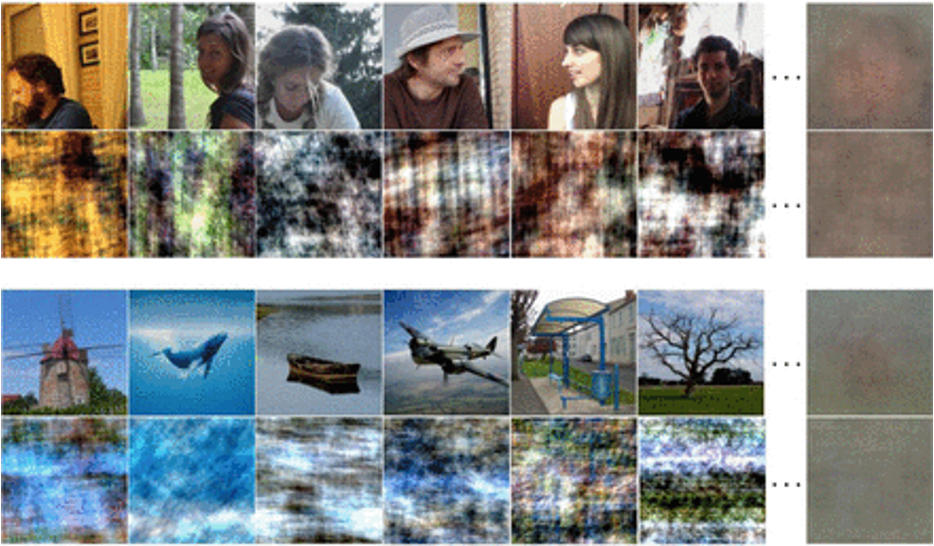

## 38 fMRI designs

- Block Designs – trials appear in alternating blocks (Task A, Task B)
- Event Related Designs – stimuli are presented one-at-a-time in a random order
- Mixed Designs – alternating blocks of tasks but with mixed trials
- (resting state fMRI) - no task

## 39 Block designs

- Powerful for detecting signal changes if a good control is selected.
- Not very good for estimating the shape of the HRF.
- Sensitive to noise (scanner drift)
- The block length is very important to consider

## 40 Event-related designs

come in two “flavours”

- Slow – stimulus followed by long inter-trial intervals (eg 10-15s rest)
- Fast/Rapid variable – rapid stimulus presentation with variable, but short ISI (2s)

## 41

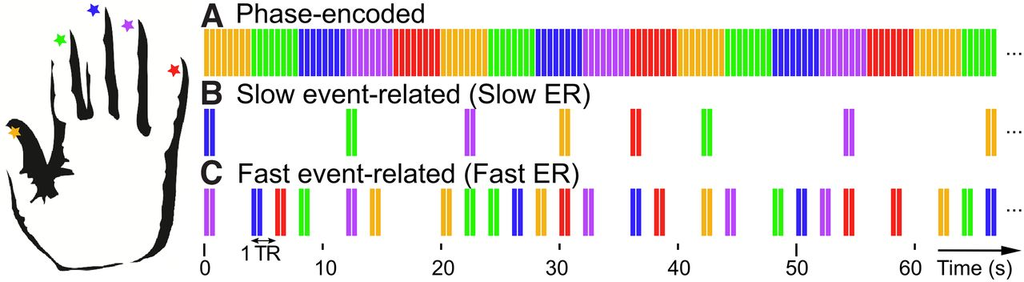

figure showing timing of events in touch experiment

## 42

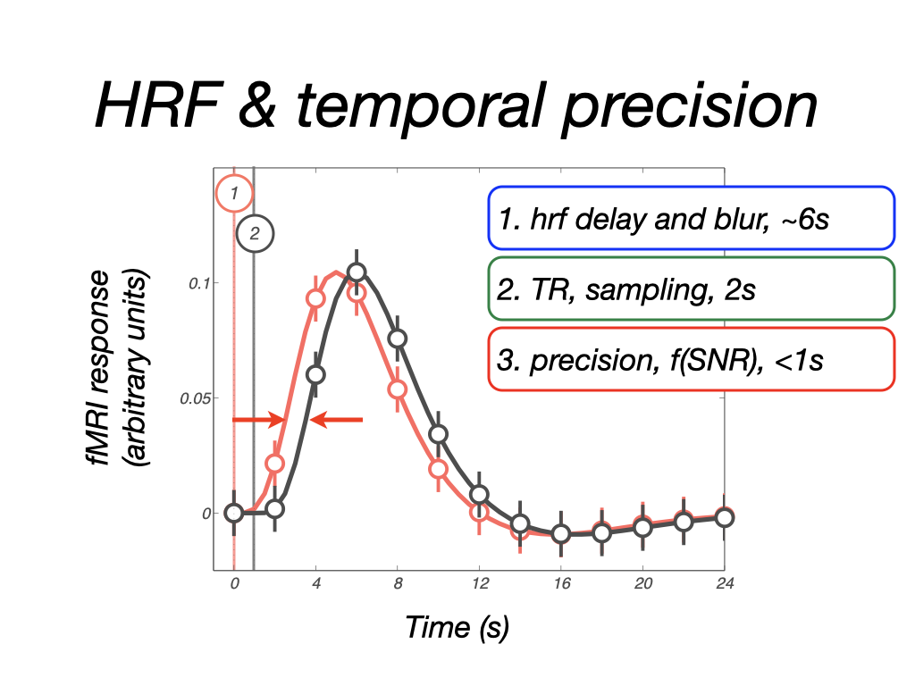

figure illustrating different aspects of temporal precision in fMRI experiments

## 43 Summary

Principles of experimental psychology apply to good fMRI study design also.

- Consider how the hypotheses make predictions about space and time (and do they align with the scope of what fMRI can measure).
- The experimental design should be appropriate for the research question.
- Timing of stimulus presentation is key!

## 44 Thanks

See you soon!

## 45 Colophon

- This presentation was made with `quarto` and `revealjs`.
- Uses a font called `Atkinson Hyerlegible`, which was designed to work better for people with low vision: available via [google fonts](https://fonts.google.com/specimen/Atkinson+Hyperlegible).